# FE8828 Assignment for Exploratory Data Analysis

Wei Kuang <sub><Email:kwan0067@e.ntu.edu.sg></sub>

Oct 2019

# Information

In this study, we examine the dataset: bank to derive insights. Below provides descriptions for each variable.

#### Personal profile:

1. **age** (numeric)
2. **job** : type of job (categorical: “admin.”,“unknown”,“unemployed”,“management”,“housemaid”,“entrepreneur”,“student”, “blue-collar”,“self-employed”,“retired”,“technician”,“services”)
3. **marital** : marital status (categorical: “married”,“divorced”,“single”; note: “divorced” means divorced or widowed)
4. **education** (categorical: “unknown”,“secondary”,“primary”,“tertiary”)
5. **default**: has credit in default? (binary: “yes”,“no”)
6. **balance**: average yearly balance, in euros (numeric)
7. **housing**: has housing loan? (binary: “yes”,“no”)
8. **loan**: has personal loan? (binary: “yes”,“no”)

#### Related with the last contact of the current campaign:

9. **contact**: contact communication type (categorical: “unknown”,“telephone”,“cellular”)
10. **day**: last contact day of the month (numeric)
11. **month**: last contact month of year (categorical: “jan”, “feb”, “mar”, …, “nov”, “dec”)
12. **duration**: last contact duration, in seconds (numeric)

#### Other attributes:

13. **campaign**: number of contacts performed during this campaign and for this client (numeric, includes last contact)
14. **pdays**: number of days that passed by after the client was last contacted from a previous campaign (numeric, -1 means client was not previously contacted)
15. **previous**: number of contacts performed before this campaign and for this client (numeric)
16. **poutcome**: outcome of the previous marketing campaign (categorical: “unknown”,“other”,“failure”,“success”)

#### Output variable (desired target):

17. **y** - has the client subscribed a term deposit? (binary: “yes”,“no”)

Also, for below analysis, derived variable: **age_group** refers to

| age_group | Age range |
| --- | --- |
| 10 | 10,19 |
| 20 | 20,29 |
| 30 | 30,39 |
| 40 | 40,49 |
| 50 | 50,59 |
| 60 | 60,69 |
| 70 | 70,79 |
| 80 | 80,89 |

# Finding #1

#### Some summary of our given data.

This data contains **4521 rows** and **17 variables**.

# Finding #2

#### What is the number of clients in each age group?

```r
# Find the big age group
bank %>%
  group_by(age_group = (age %/% 10) * 10) %>%
  summarise(count = n()) %>%
  arrange(age_group) -> res

res
```

```
## # A tibble: 8 x 2
##   age_group count
##       <dbl> <int>
## 1        10     4
## 2        20   478
## 3        30  1808
## 4        40  1203
## 5        50   854
## 6        60   113
## 7        70    47
## 8        80    14
```

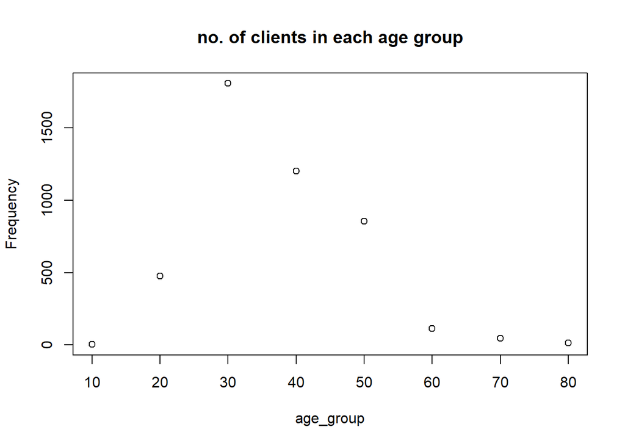

```r
plot(res$age_group, res$count, main = "no. of clients in each age group", ylab = "Frequency", xlab = "age_group")
```

The largest age group is **age range from 30 to 39** with **1808 clients**.

# Discover insights of data frame: bank

- Employment
- Social attributes.
- Count for sub-total / total, plot graph

# Finding #3

#### What is the proportion of non-working clients in each age group?

```r
# Find the number and % of non-working clients
# Non-working is defined as job = "unknown", "unemployed", "housemaid", "student" and "retired"
# Assumption is made for job = "unknown" as non-working
df <- mutate(bank, `non-working` = ifelse(job %in% c("unknown", "unemployed", "housemaid", "student", "retired"), T, F), age_group = (age %/% 10) * 10)

df2 <- group_by(df, age_group) %>%
  summarise(`no. of non-working` = sum(`non-working`), `% of non-working` = sum(`non-working`)/n()*100)

# Find the overall number and % of non-working clients
df3 <- summarise(df, `no. of non-working` = sum(`non-working`), `% of non-working` = sum(`non-working`)/n()*100)

bind_rows(df2, df3)
```

```
## # A tibble: 9 x 3
##   age_group `no. of non-working` `% of non-working`
##       <dbl>                <int>              <dbl>
## 1        10                    4             100
## 2        20                   83              17.4
## 3        30                   96               5.31
## 4        40                   90               7.48
## 5        50                  198              23.2
## 6        60                   64              56.6
## 7        70                   44              93.6
## 8        80                   13              92.9
## 9        NA                  592              13.1
```

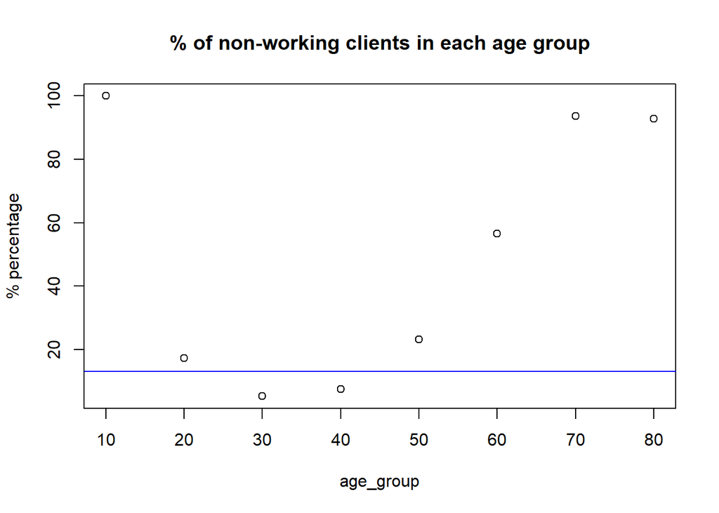

```r
plot(df2$age_group, df2$`% of non-working`, type = "p", main = "% of non-working clients in each age group", ylab = "% percentage", xlab = "age_group")
abline(h=df3$`% of non-working`, col="blue")
```

As compared to an **overall 13.1%** of non-working clients, **all age groups except age range from 30 to 49 have higher % of non-working clients**.

# Finding #4

#### How different is the balance in each age group?

```r
# Find the clients with the minimum and maximum balance in each age group, re-arrange columns to show the age_group and balance first
# Also, find the mean balance and range of balance (i.e. max-min) in each age group
df4 <- group_by(df, age_group) %>%
  dplyr::filter(min_rank(balance) == 1 | min_rank(desc(balance)) == 1) %>%
  select(age_group, balance, everything()) %>%
  arrange(age_group, balance)

df4
```

```
## # A tibble: 19 x 19
## # Groups:   age_group [8]
##    age_group balance   age job   marital education default housing loan
##        <dbl>   <int> <int> <fct> <fct>   <fct>     <fct>   <fct>   <fct>
##  1        10       0    19 stud~ single  unknown   no      no      no
##  2        10    1169    19 stud~ single  unknown   no      no      no
##  3        20   -1202    27 serv~ married secondary no      yes     no
##  4        20   22171    29 admi~ married secondary no      yes     no
##  5        30   -1053    32 tech~ married tertiary  no      yes     no
##  6        30   27359    36 mana~ married tertiary  no      yes     no
##  7        40   -1746    44 mana~ married secondary no      yes     no
##  8        40   42045    42 entr~ married tertiary  no      no      no
##  9        50   -3313    57 self~ married tertiary  yes     yes     yes
## 10        50   27069    57 tech~ married tertiary  no      no      yes
## 11        60    -396    60 admi~ married secondary no      yes     no
## 12        60   71188    60 reti~ married primary   no      no      no
## 13        70       0    77 reti~ married tertiary  no      no      no
## 14        70   26452    75 reti~ married secondary no      no      no
## 15        80       0    83 reti~ married secondary no      no      no
## 16        80       0    80 hous~ married primary   no      no      no
## 17        80       0    83 reti~ divorc~ primary   no      no      no
## 18        80    8304    80 reti~ married secondary no      no      no
## 19        80    8304    80 reti~ married secondary no      no      no
## # ... with 10 more variables: contact <fct>, day <int>, month <fct>,
## #   duration <int>, campaign <int>, pdays <int>, previous <int>,
## #   poutcome <fct>, y <fct>, `non-working` <lgl>
```

```r
df5 <- group_by(df, age_group) %>%
  summarise(balance1 = mean(balance)) %>%
  rename(`Mean balance` = balance1)

group_by(df4, age_group) %>%
  summarise(balance2 = max(balance)-min(balance)) %>%
  rename(`Range balance` = balance2) %>%
  inner_join(., df5, by = "age_group")
```

```
## # A tibble: 8 x 3
##   age_group `Range balance` `Mean balance`
##       <dbl>           <int>          <dbl>
## 1        10            1169           394.
## 2        20           23373          1064.
## 3        30           28412          1298.
## 4        40           43791          1475.
## 5        50           30382          1547.
## 6        60           71584          2620.
## 7        70           26452          3281.
## 8        80            8304          2071.
```

**Age range from 60 to 69 has the largest range in terms of balance (i.e. max-min)**, while **age range from 70 to 79 has the higehst mean balance**. *Also, an interesting note for the age group of 80 is that there are some clients who have same min/max balance. Hence, more than 2 records are shown in df4 for age group of 80.*

# Finding 5

### Does education affects the subscription of term deposit?

```r
# Find the number of clients by education and subscription to term deposit
df6 <- group_by(df, y, education) %>%
  summarise(count = n())

df7<- group_by(df6, y) %>%
  summarise(value1 = sum(count)) %>%
  rename(count = value1) %>%
  mutate(education = "overall") %>%
  spread(key = education, value = count) %>%
  inner_join(spread(df6, key= education, value=count), ., by = "y")

col_total <- gather(df7, key, value, -y) %>%
  group_by(key) %>%
  summarise(value2 = sum(value)) %>%
  rename(count = value2) %>%
  spread(key=key, value=count)

df8 <- bind_rows(df7, col_total)
df8
```

[output not shown]

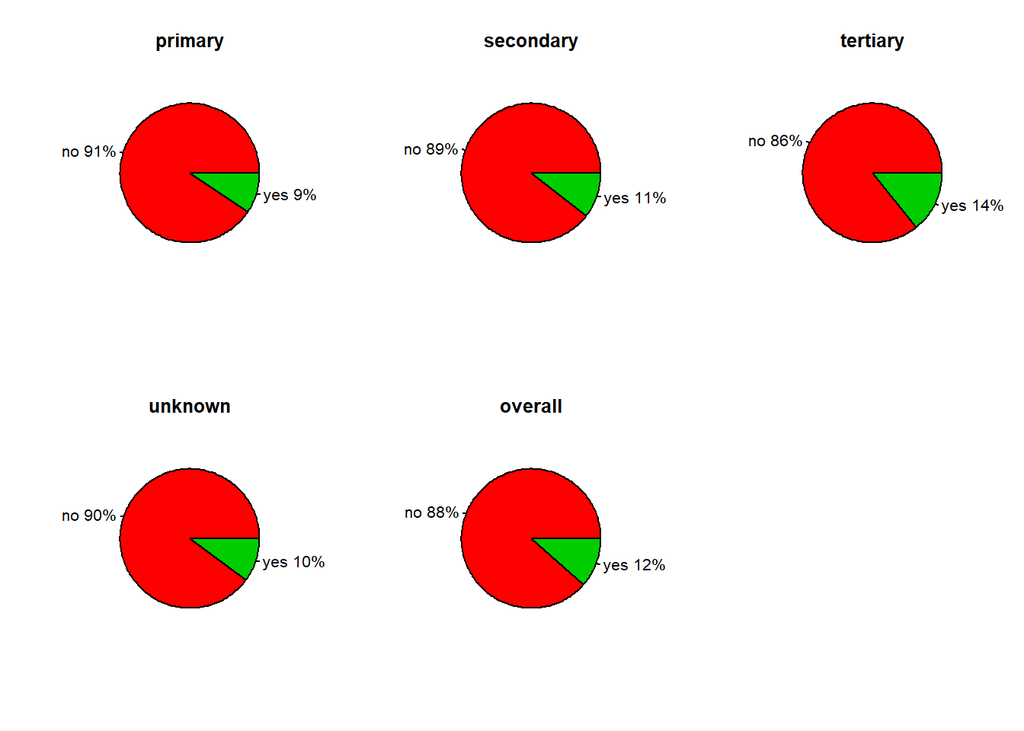

```r
#Plot pie chart to see the proportion
par(mfrow=c(2,3))
for (i in 2:6){
  x <- c(as.numeric(df8[1,i]), as.numeric(df8[2,i]))
  labels <- c("no", "yes")
  pct <- round(x/sum(x)*100)
  lbls <- paste(labels, pct) # add percents to labels
  lbls <- paste(lbls,"%",sep="") # add % to labels
  pie(x, labels = lbls, col=(c(2,3)),main=names(df8[i]))
}
```

From the pie chart, **tertiary education has the highest percentage (14%) of subscription to term deposit**. Also, **it is higher than the overall average of 12%**.

# Finding 6

### Of those that have credit in default, how many of them have either housing loan or personal loan or both?

```r
# Filter for those that have credit in default and make a table on have loans vs no loans
df9 <- dplyr::filter(bank, default == "yes") %>%
  mutate(have_loan = case_when(
    housing == "yes" | loan == "yes" ~ "yes",
    TRUE ~ "no"
    )) %>%
  group_by(have_loan) %>%
  summarise(count = n()) %>%
  mutate(percentage = count/sum(.$count)*100)

bind_rows(df9, data.frame(count=sum(df9$count), percentage = 100))
```

```
## # A tibble: 3 x 3
##   have_loan count percentage
##   <chr>     <int>      <dbl>
## 1 no           17       22.4
## 2 yes          59       77.6
## 3 <NA>         76      100
```

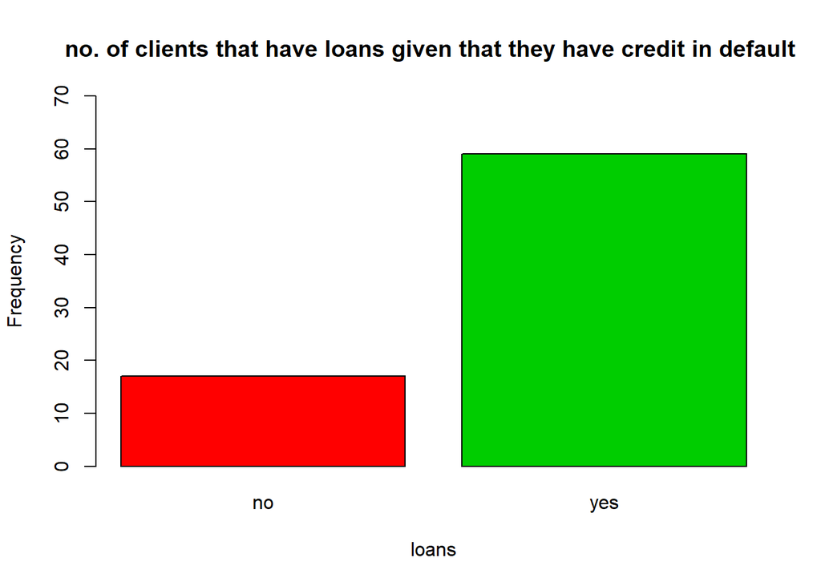

```r
#Plot bar graph
barplot(df9$count, main = "no. of clients that have loans given that they have credit in default ", ylab = "Frequency", xlab = "loans", names.arg = df9$have_loan, ylim = c(0,70), col=c(2,3))
```

A **large proportion = 78%** of those that have credit in default have either housing loan or personal loan or both.

# Finding 7

### Of the top 10 clients with the highest balance, what is their profiles in terms of marital, education, default and subscription of term deposit?

```r
# Filter for top 10 clients with highest balance first and then examine their profiles
df10 <- dplyr::filter(bank, min_rank(desc(balance)) %in% c(1:10)) %>%
  arrange(desc(balance))
df10
```

```
##    age          job  marital education default balance housing loan
## 1   60      retired  married   primary      no   71188      no   no
## 2   42 entrepreneur  married  tertiary      no   42045      no   no
## 3   43   technician   single  tertiary      no   27733     yes   no
## 4   36   management  married  tertiary      no   27359     yes   no
## 5   57   technician  married  tertiary      no   27069      no  yes
## 6   31    housemaid   single   primary      no   26965      no   no
## 7   75      retired  married secondary      no   26452      no   no
## 8   50     services  married secondary      no   26394      no   no
## 9   54   management divorced  tertiary      no   26306     yes   no
## 10  49      retired   single   primary      no   25824      no   no
##      contact day month duration campaign pdays previous poutcome   y
## 1   cellular   6   oct      205        1    -1        0  unknown  no
## 2   cellular   8   aug      205        2    -1        0  unknown  no
## 3    unknown   3   jun      164        7    -1        0  unknown  no
## 4    unknown   3   jun       71        2    -1        0  unknown  no
## 5    unknown  20   jun      174        3    -1        0  unknown  no
## 6   cellular  21   apr      654        2    -1        0  unknown yes
## 7  telephone  15   jul      219        2    -1        0  unknown  no
## 8   cellular  25   aug      206        4    -1        0  unknown  no
## 9   cellular  11   feb       27        1    84        3  failure  no
## 10   unknown  17   jun       94        1    -1        0  unknown  no
```

```r
top10_marital <- group_by(df10, marital) %>%
  summarise(count=n()) %>%
  mutate(percentage = count/sum(.$count)*100) %>%
  bind_rows(., data.frame(count=sum(.$count), percentage = 100))

top10_educ <- group_by(df10, education) %>%
  summarise(count=n()) %>%
  mutate(percentage = count/sum(.$count)*100) %>%
  bind_rows(., data.frame(count=sum(.$count), percentage = 100))

top10_default <- group_by(df10, default) %>%
  summarise(count=n()) %>%
  mutate(percentage = count/sum(.$count)*100) %>%
  bind_rows(., data.frame(count=sum(.$count), percentage = 100))

top10_y <- group_by(df10, y) %>%
  summarise(count=n()) %>%
  mutate(percentage = count/sum(.$count)*100) %>%
  bind_rows(., data.frame(count=sum(.$count), percentage = 100))

top10_marital
```

```
## # A tibble: 4 x 3
##   marital  count percentage
##   <fct>    <int>      <dbl>
## 1 divorced     1         10
## 2 married      6         60
## 3 single       3         30
## 4 <NA>        10        100
```

```r
top10_educ
```

```
## # A tibble: 4 x 3
##   education count percentage
##   <fct>     <int>      <dbl>
## 1 primary       3         30
## 2 secondary     2         20
## 3 tertiary      5         50
## 4 <NA>         10        100
```

```r
top10_default
```

```
## # A tibble: 2 x 3
##   default count percentage
##   <fct>   <int>      <dbl>
## 1 no         10        100
## 2 <NA>       10        100
```

```r
top10_y
```

```
## # A tibble: 3 x 3
##   y     count percentage
##   <fct> <int>      <dbl>
## 1 no        9         90
## 2 yes       1         10
## 3 <NA>     10        100
```

Examing the top 10 clients with the highest balance, **60% are married**, **50% have tertiary education**, **none has credit in default** and only **10% subscribed to term deposit**.

# Finding 8

### More days between campaigns help/do not help in the subscription of term deposit?

```r
#Find the number of clients that was previously contacted
transmute(bank, prev_contacted = ifelse(pdays == -1, FALSE, TRUE)) %>%
  summarise(`Previously contacted` = sum(prev_contacted)) %>%
  mutate(Total = length(bank$age)) %>%
  mutate(`Not Previously contacted` = Total - `Previously contacted`) %>%
  select(`Previously contacted`, `Not Previously contacted`, Total)
```

```
##   Previously contacted Not Previously contacted Total
## 1                  816                     3705  4521
```

```r
#Filter for those previously contacted (816 clients in this case)
#Find number of clients who subscribed out of these 816 clients
dplyr::filter(bank,pdays != -1 & y=="yes") %>%
  summarise(success = n())
```

```
##   success
## 1     184
```

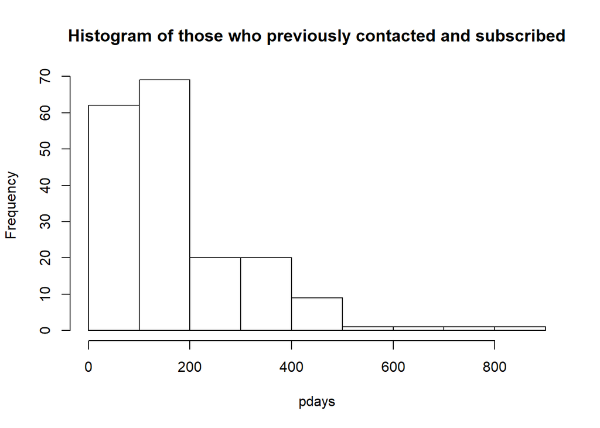

```r
df11 <- dplyr::filter(bank,pdays != -1 & y == "yes") %>%
  select(pdays)
hist(df11$pdays, main = "Histogram of those who previously contacted and subscribed",
     xlab = "pdays", ylab = "Frequency")
```

Of 4521 clients, there are **816 clients that are previously contacted**. **Only 184 of the 816 subscribed term deposit**. From the histogram, it seems like it is best to have **less than 200 days** between campaigns.

# Finding 9

### With relate to the last contact of the current campaign, which month was the most active?

```r
firstup <- function(x) {
  substr(x, 1, 1) <- toupper(substr(x, 1, 1))
  x
}
mutate(bank, month_name = factor(firstup(as.character(month)), levels = month.abb)) %>%
  group_by(month_name) %>%
  summarise(count=n()) %>%
  mutate(percentage = round(count/sum(.$count)*100,1)) %>%
  bind_rows(., data.frame(count=sum(.$count), percentage = 100))
```

```
## # A tibble: 13 x 3
##    month_name count percentage
##    <fct>      <int>      <dbl>
##  1 Jan          148        3.3
##  2 Feb          222        4.9
##  3 Mar           49        1.1
##  4 Apr          293        6.5
##  5 May         1398       30.9
##  6 Jun          531       11.7
##  7 Jul          706       15.6
##  8 Aug          633       14
##  9 Sep           52        1.2
## 10 Oct           80        1.8
## 11 Nov          389        8.6
## 12 Dec           20        0.4
## 13 <NA>        4521      100
```

From the table, **May is the month that is most active**.

# Finding 10

### Is there any combination between marital and education that the data has not consider?

```r
#Consider all possible combination between marital and education
df12 <- full_join(distinct(bank, marital) %>% mutate(dummy = 1),
               distinct(bank, education) %>% mutate(dummy = 1),
               by = "dummy") %>%
  select(-dummy)
df13 <- distinct(bank, marital, education)

nrow(df12)
```

```
## [1] 12
```

```r
nrow(df13)
```

```
## [1] 12
```

```r
anti_join(df12, df13, by = c("marital", "education"))
```

```
## [1] marital   education
## <0 rows> (or 0-length row.names)
```

```r
anti_join(df13, df12, by = c("marital", "education"))
```

```
## [1] marital   education
## <0 rows> (or 0-length row.names)
```

There is **no combination between marital and education** that the data has not consider.